# Unsupervised Model

李哲

5/16/2022

## 导入所需的包

```r
# 清理工作环境
rm(list=ls())
# 加载所需要的包
library(dplyr)
library(lubridate)
library(stringr)
library(openxlsx)
library(ggplot2)
library(ggpubr)
library(corrplot)
library(psych)
library(randomForest)
library(GGally)
```

## 读取数据

```r
# 读取数据
data_soccer <- read.csv("data_soccer.csv", check.names = F, fileEncoding = 'utf-8')
# command + shift + m
# dplyr
data_soccer %>% head()
```

```
##           球员 所属球队 出场（替补） 出场时间 进球（点球） 分钟/球 射门 射正
## 1       托马斯 阿拉维斯        24(6)     1472            5   294.4   32    9
## 2     M.加西亚 阿拉维斯        34(9)     2325            2  1162.5   30    7
## 3 马丁阿古拉甘 阿拉维斯        26(3)     2043            0     0.0    1    0
## 4         伊利 阿拉维斯            5      431            0     0.0    2    1
## 5    迭戈.罗兰 阿拉维斯       15(10)      507            0     0.0   10    2
## 6       高美思 阿拉维斯         5(3)      278            0     0.0    2    0
##   入球转化率 被侵犯 越位 最佳       生日 惯用脚           国籍 合同截止期 位置
## 1      15.6%     13   11    1 1992-08-25   右脚         西班牙 2019-06-30 前锋
## 2       6.7%     53    4    0 1986-04-26   左脚         西班牙 2019-06-30 中场
## 3         0%     28    0    0 1996-05-10   右脚         西班牙 2022-06-30 后卫
## 4         0%      2    0    0 1993-11-03   右脚   巴西、意大利 2021-06-30 后卫
## 5         0%     17    0    0 1993-03-24   右脚 乌拉圭、意大利 2019-06-30 前锋
## 6         0%      3    0    0 1997-01-09   左脚         西班牙 2021-06-30 后卫
##   铲断 拦截 解围 偷球 封堵 头球 犯规 总传球 传球成功率 关键传球 助攻 分钟/助攻
## 1   15    5   11   15    5   47   41    308      0.627        8    1      1472
## 2   83   26   59   27    7  107   62    932      0.739       12    1      2325
## 3   42   26   56   10   11   20   24    717      0.688        8    0         0
## 4    7    8   25    0    7   24    7    158      0.696        2    0         0
## 5   13    4    8   15    0    9   10    164      0.780        5    0         0
## 6   11    7    9    0    0    5    9     81      0.691        0    0         0
##   长传 直塞 带球摆脱 联赛 名次 身价 是否为欧盟
## 1   10    0        5 西甲  100  180       欧盟
## 2   85    0       12 西甲  100  162       欧盟
## 3  123    0       25 西甲  100  135       欧盟
## 4   43    0        0 西甲  100  540       欧盟
## 5    7    0       12 西甲  100  315       欧盟
## 6   13    0        1 西甲  100   90       欧盟
```

## 数据处理

```r
data_soccer %>%
  mutate(生日 = as.Date(生日),
           年龄 = round(as.numeric(difftime(as.Date("2019-07-01"), 生日, units = "days")/365), 0),
           年龄区间 = cut(年龄, c(0, 20, 23, 25, 28, 30, 35, 40)),
           合同截止期 = as.Date(合同截止期),
           合同剩余时间 = -round(as.numeric(difftime(as.Date("2019-07-01"), 合同截止期, units = "days")/365), 0),
           合同剩余时间 = ifelse(合同剩余时间 > 5, 5, 合同剩余时间)) -> temp1

temp1 %>% head()
```

```
##           球员 所属球队 出场（替补） 出场时间 进球（点球） 分钟/球 射门 射正
## 1       托马斯 阿拉维斯        24(6)     1472            5   294.4   32    9
## 2     M.加西亚 阿拉维斯        34(9)     2325            2  1162.5   30    7
## 3 马丁阿古拉甘 阿拉维斯        26(3)     2043            0     0.0    1    0
## 4         伊利 阿拉维斯            5      431            0     0.0    2    1
## 5    迭戈.罗兰 阿拉维斯       15(10)      507            0     0.0   10    2
## 6       高美思 阿拉维斯         5(3)      278            0     0.0    2    0
##   入球转化率 被侵犯 越位 最佳       生日 惯用脚           国籍 合同截止期 位置
## 1      15.6%     13   11    1 1992-08-25   右脚         西班牙 2019-06-30 前锋
## 2       6.7%     53    4    0 1986-04-26   左脚         西班牙 2019-06-30 中场
## 3         0%     28    0    0 1996-05-10   右脚         西班牙 2022-06-30 后卫
## 4         0%      2    0    0 1993-11-03   右脚   巴西、意大利 2021-06-30 后卫
## 5         0%     17    0    0 1993-03-24   右脚 乌拉圭、意大利 2019-06-30 前锋
## 6         0%      3    0    0 1997-01-09   左脚         西班牙 2021-06-30 后卫
##   铲断 拦截 解围 偷球 封堵 头球 犯规 总传球 传球成功率 关键传球 助攻 分钟/助攻
## 1   15    5   11   15    5   47   41    308      0.627        8    1      1472
## 2   83   26   59   27    7  107   62    932      0.739       12    1      2325
## 3   42   26   56   10   11   20   24    717      0.688        8    0         0
## 4    7    8   25    0    7   24    7    158      0.696        2    0         0
## 5   13    4    8   15    0    9   10    164      0.780        5    0         0
## 6   11    7    9    0    0    5    9     81      0.691        0    0         0
##   长传 直塞 带球摆脱 联赛 名次 身价 是否为欧盟 年龄 年龄区间 合同剩余时间
## 1   10    0        5 西甲  100  180       欧盟   27  (25,28]            0
## 2   85    0       12 西甲  100  162       欧盟   33  (30,35]            0
## 3  123    0       25 西甲  100  135       欧盟   23  (20,23]            3
## 4   43    0        0 西甲  100  540       欧盟   26  (25,28]            2
## 5    7    0       12 西甲  100  315       欧盟   26  (25,28]            0
## 6   13    0        1 西甲  100   90       欧盟   22  (20,23]            2
```

```r
# 将球员生日转化为日期格式
data_soccer$生日 <- as.Date(data_soccer$生日)
# 计算球员年龄
data_soccer$年龄 <- round(as.numeric(difftime(as.Date("2019-07-01"), data_soccer$生日, units = "days")/365), 0)
# 将年龄划分区间
data_soccer$年龄区间 <- cut(data_soccer$年龄, c(0, 20, 23, 25, 28, 30, 35, 40))

# 将合同到期时间转化为时间格式
data_soccer$合同截止期 <- as.Date(data_soccer$合同截止期)
# 计算剩余时间
data_soccer$`合同剩余时间` <- -round(as.numeric(difftime(as.Date("2019-07-01"), data_soccer$合同截止期, units = "days")/365), 0)
# 5年以上替换为5年
data_soccer$`合同剩余时间`[data_soccer$`合同剩余时间`>5] <- 5
```

```r
data_soccer %>%
  mutate(名次 = as.numeric(as.character(名次))) %>%
  mutate(名次 = ifelse(is.na(名次) | 名次 > 200, 200, 名次),
           排名区间 = cut(名次, c(0, 25, 50, 75, 100, 125, 150, 200))) -> temp2
temp2 %>% head()
```

```
##           球员 所属球队 出场（替补） 出场时间 进球（点球） 分钟/球 射门 射正
## 1       托马斯 阿拉维斯        24(6)     1472            5   294.4   32    9
## 2     M.加西亚 阿拉维斯        34(9)     2325            2  1162.5   30    7
## 3 马丁阿古拉甘 阿拉维斯        26(3)     2043            0     0.0    1    0
## 4         伊利 阿拉维斯            5      431            0     0.0    2    1
## 5    迭戈.罗兰 阿拉维斯       15(10)      507            0     0.0   10    2
## 6       高美思 阿拉维斯         5(3)      278            0     0.0    2    0
##   入球转化率 被侵犯 越位 最佳       生日 惯用脚           国籍 合同截止期 位置
## 1      15.6%     13   11    1 1992-08-25   右脚         西班牙 2019-06-30 前锋
## 2       6.7%     53    4    0 1986-04-26   左脚         西班牙 2019-06-30 中场
## 3         0%     28    0    0 1996-05-10   右脚         西班牙 2022-06-30 后卫
## 4         0%      2    0    0 1993-11-03   右脚   巴西、意大利 2021-06-30 后卫
## 5         0%     17    0    0 1993-03-24   右脚 乌拉圭、意大利 2019-06-30 前锋
## 6         0%      3    0    0 1997-01-09   左脚         西班牙 2021-06-30 后卫
##   铲断 拦截 解围 偷球 封堵 头球 犯规 总传球 传球成功率 关键传球 助攻 分钟/助攻
```

[output cut: 20 more lines]

```r
# 将名次这一变量转换为数值型
data_soccer$名次 <- as.numeric(as.character(data_soccer$名次))
# 替换缺失和大于200的
data_soccer[which(is.na(data_soccer$名次) == T | data_soccer$名次 > 200),]$名次 <- 200
# 划分区间
data_soccer$排名区间 <- cut(data_soccer$名次,c(0, 25, 50, 75, 100, 125, 150, 200))
```

```r
data_soccer %>%
  mutate(入球转化率 = as.numeric(str_extract(入球转化率, "[0-9]+"))/100,
              进球 = as.numeric(str_extract(`进球（点球）`, "\\d+"))) %>%
  head()
```

```
##           球员 所属球队 出场（替补） 出场时间 进球（点球） 分钟/球 射门 射正
## 1       托马斯 阿拉维斯        24(6)     1472            5   294.4   32    9
## 2     M.加西亚 阿拉维斯        34(9)     2325            2  1162.5   30    7
## 3 马丁阿古拉甘 阿拉维斯        26(3)     2043            0     0.0    1    0
## 4         伊利 阿拉维斯            5      431            0     0.0    2    1
## 5    迭戈.罗兰 阿拉维斯       15(10)      507            0     0.0   10    2
## 6       高美思 阿拉维斯         5(3)      278            0     0.0    2    0
##   入球转化率 被侵犯 越位 最佳       生日 惯用脚           国籍 合同截止期 位置
## 1       0.15     13   11    1 1992-08-25   右脚         西班牙 2019-06-30 前锋
## 2       0.06     53    4    0 1986-04-26   左脚         西班牙 2019-06-30 中场
## 3       0.00     28    0    0 1996-05-10   右脚         西班牙 2022-06-30 后卫
## 4       0.00      2    0    0 1993-11-03   右脚   巴西、意大利 2021-06-30 后卫
## 5       0.00     17    0    0 1993-03-24   右脚 乌拉圭、意大利 2019-06-30 前锋
## 6       0.00      3    0    0 1997-01-09   左脚         西班牙 2021-06-30 后卫
##   铲断 拦截 解围 偷球 封堵 头球 犯规 总传球 传球成功率 关键传球 助攻 分钟/助攻
```

[output cut: 20 more lines]

```r
# 提取入球转化率
data_soccer$`入球转化率` <- as.numeric(str_extract(data_soccer$入球转化率, "[0-9]+"))/100
# 提取进球数
data_soccer$`进球` <- as.numeric(str_extract(data_soccer$`进球（点球）`, "\\d+"))
```

构造新变量：mutate 去重：distinct 分组：group_by 前n条：head 排序：arrange 拼接：left_join、right_join、inner_join

## 描述性分析

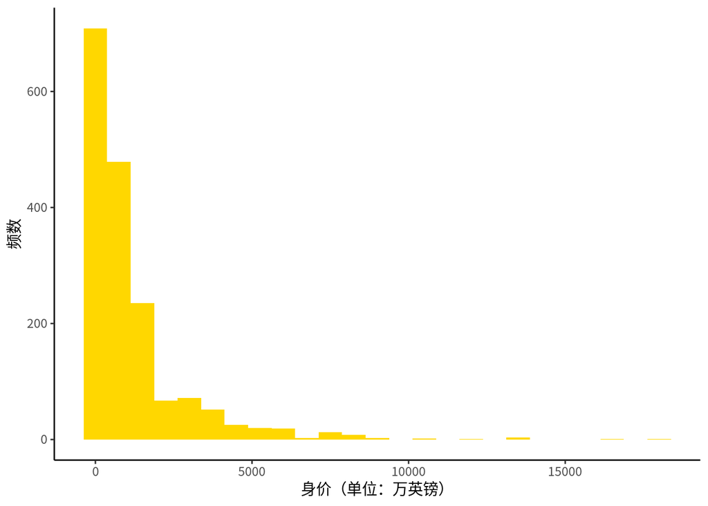

```r
ggplot(data_soccer)+
  # 填充颜色为金色，柱子个数为25
  geom_histogram(aes(x=身价), fill="gold",bins=25)+
  # 设置字体
  theme_bw(base_family = "Hei")+  # STXihei
  # 设置背景
  theme(panel.border = element_blank(),
        panel.grid.major = element_blank(),
        panel.grid.minor = element_blank(),
        axis.line = element_line(colour = "black"))+
  # 添加坐标轴标签
  ylab("频数")+
  xlab("身价（单位：万英镑）")
```

```r
#查看身价的基本信息
data_soccer$身价 %>% summary()
```

```
##    Min. 1st Qu.  Median    Mean 3rd Qu.    Max.
##       0     180     540    1182    1350   18000
```

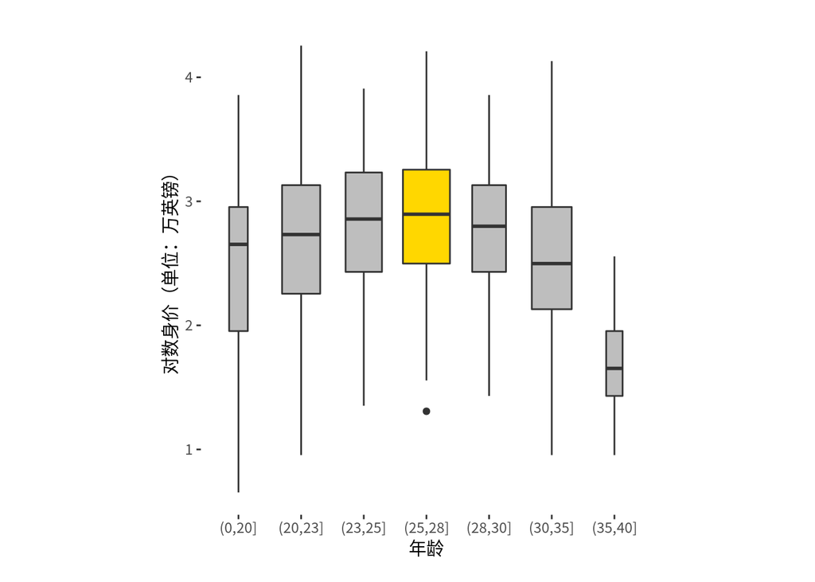

```r
# 计算各个区间的频数和身价均值
data_age <- data_soccer %>%
  group_by(年龄区间) %>%
  summarise(mean=mean(身价), count=n()) %>%
  na.omit()

# 绘制各年龄段身价箱线图
data_soccer[which(is.na(data_soccer$年龄区间) == F),] %>%
  ggplot() +
  # 绘制分组箱线图，按照年龄大小排序，身价最高的标为金色，其余为灰色
  geom_boxplot(aes(x = 年龄区间, y = log10(身价)), varwidth = T, fill = c(rep("grey", 3), rep("gold", 1), rep("grey", 3)))+
  theme_bw(base_family = "STXihei")+
  theme(panel.border = element_blank(),
        panel.grid.major = element_blank(),
        panel.grid.minor = element_blank())+
  xlab("年龄")+
  ylab("对数身价（单位：万英镑）")+
  theme(plot.margin = unit(c(1,7,1,7), 'lines'))
```

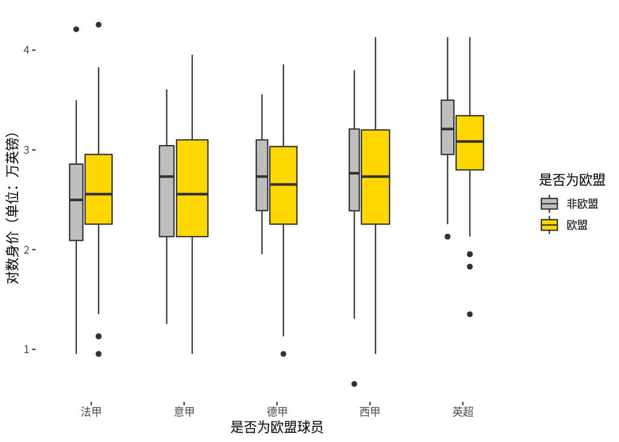

```r
# 绘制不同联赛欧盟与非欧盟球员的对比箱线图
data_soccer %>%
  ggplot()+
  # 绘制分组箱线图（x轴为五大联赛，颜色区分欧盟和非欧盟）
  geom_boxplot(aes(x=reorder(联赛, X = 身价, FUN = mean), y = log10(身价), fill = 是否为欧盟), varwidth = T)+
  # 设置字体
  theme_bw(base_family = "STXihei")+
  # 设置图例
  labs(fill = "是否为欧盟")+
  # 填充颜色
  scale_fill_manual(values = c("grey","gold"))+
  # 设置背景
  theme(panel.border = element_blank(),
        panel.grid.major = element_blank(),
        panel.grid.minor = element_blank())+
  # 添加坐标轴标签
  xlab("是否为欧盟球员")+
  ylab("对数身价（单位：万英镑）")
```

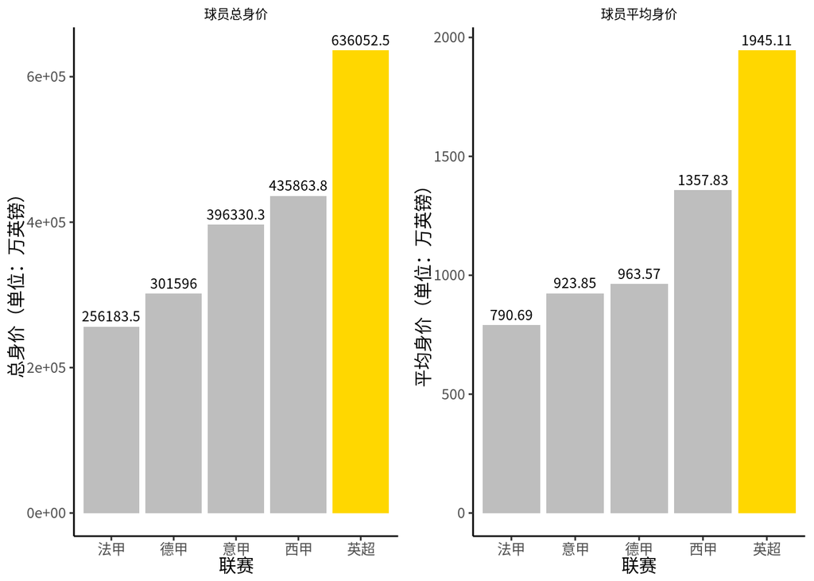

```r
# 计算不同联赛身价的均值
data_league <- data_soccer %>%
  group_by(联赛) %>%
  summarise(sum = sum(身价), mean = mean(身价))
# 绘制不同联赛总身价的柱状图
ggplot(data_league)+
  # 绘制柱状图，并按照总身价进行排序
  geom_bar(aes(x=reorder(联赛,X=sum),y=sum),stat = "identity",fill=c(rep("grey",4),"gold"))+
  # 添加数字标签
  geom_text(aes(x=reorder(联赛,X=sum),y=sum,label=round(sum,2),vjust=-0.5),size=3)+
  # 设置字体
  theme_bw(base_family = "Hei")+  # STXihei
  # 设置背景
  theme(panel.border = element_blank(),
        panel.grid.major = element_blank(),
        panel.grid.minor = element_blank(),
        axis.line = element_line(colour = "black"))+
  # 添加坐标轴信息
  xlab("联赛")+
  ylab("总身价（单位：万英镑）")+
  ggtitle("球员总身价")+
  theme(plot.title=element_text(hjust=0.5,size=8)) -> p1

# 绘制不同联赛身价的均值柱状图
ggplot(data_league)+
  # 绘制柱状图，并按照均值进行排序
  geom_bar(aes(x = reorder(联赛, X = mean), y = mean), stat = "identity", fill = c(rep("grey", 4), "gold"))+
  geom_text(aes(x = reorder(联赛, X = mean), y = mean, label = round(mean, 2), vjust = -0.5), size = 3)+
  # 设置字体
  theme_bw()+  # STXihei
  # 设置背景
  theme(panel.border = element_blank(),
        panel.grid.major = element_blank(),
        panel.grid.minor = element_blank(),
        axis.line = element_line(colour = "black"))+
  # 添加坐标轴信息
  xlab("联赛")+
  ylab("平均身价（单位：万英镑）")+
  # 添加标题
  ggtitle("球员平均身价")+
   #设置标题位置
  theme(plot.title = element_text(hjust=0.5,size=8),
        text = element_text(family = "Hei")) -> p2  # STXihei

# 排版
ggarrange(p1,p2,ncol=2,nrow=1)
```

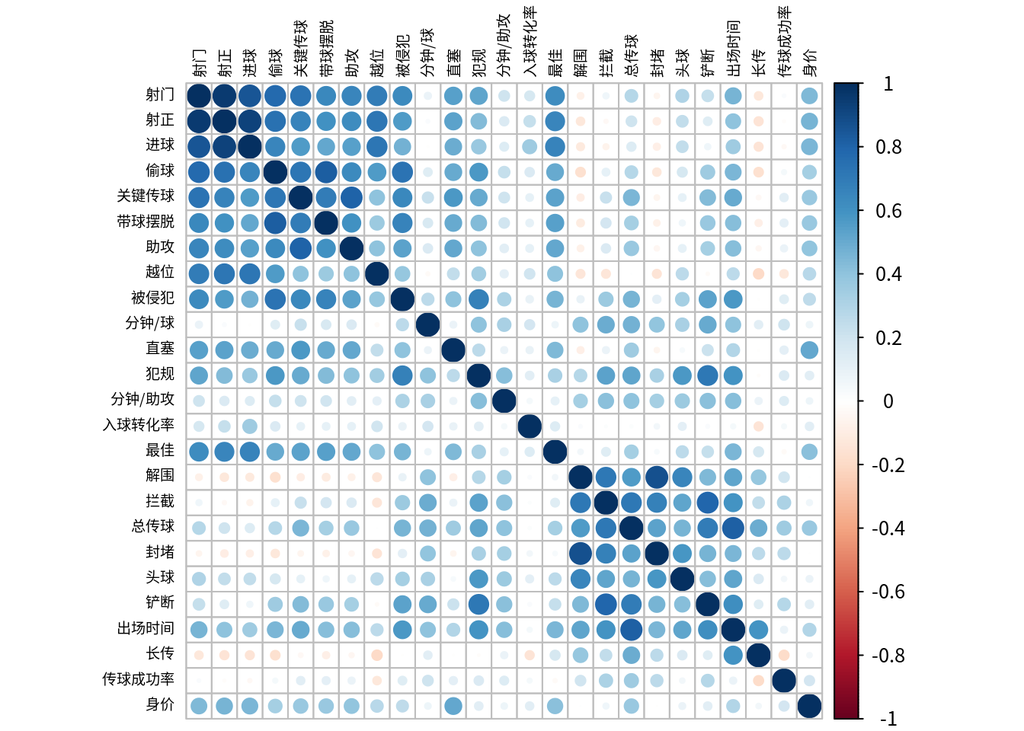

```r
#提取球员比赛数据
data_ability <- select(data_soccer,"球员","射门","射正","进球","偷球","关键传球","带球摆脱","助攻","越位","被侵犯","分钟/球","直塞","犯规","分钟/助攻","入球转化率","最佳","解围","拦截","总传球","封堵","头球","铲断","出场时间", "长传","传球成功率","身价" )

# 转化为数值型变量
data_ability[,-1] = apply(data_ability[,-1],2,function(x) as.numeric(x))

# 计算相关系数矩阵
r <- cor(data_ability[, -1])
# 绘制相关系数图
par(family = "Hei") # STXihei
corrplot(r, tl.col = "black", tl.cex = 0.6)
```

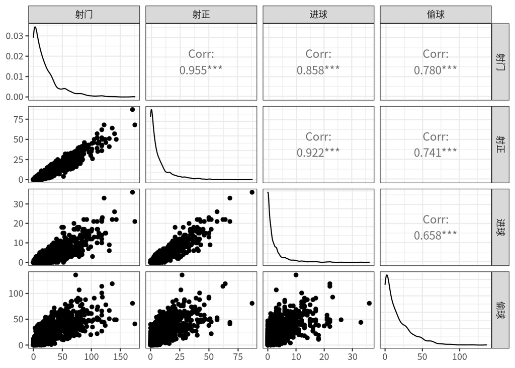

```r
ggpairs(data_ability[, 2:5]) +
  theme_bw() +
  theme(text = element_text(family = "Hei"))  # STXihei
```

## 聚类模型

### K-means

1. 选择初始化的 $\mathrm{k}$ 个样本作为初始聚类中心 $a=a_{1}, a_{2}, \ldots a_{k}$;
2. 针对数据集中每个样本 $x_{i}$ 计算它到 $\mathrm{k}$ 个聚类中心的距离并将其分到距离最小的聚类中心所对 应的类中;
3. 针对每个类别 $a_{j}$, 重新计算它的聚类中心 $a_{j}=\frac{1}{\left|c_{i}\right|} \sum_{x \in c_{i}} x$ (即属于该类的所有样本的质心）;
4. 重复上面 23 两步操作, 直到达到某个中止条件（迭代次数、最小误差变化等）。

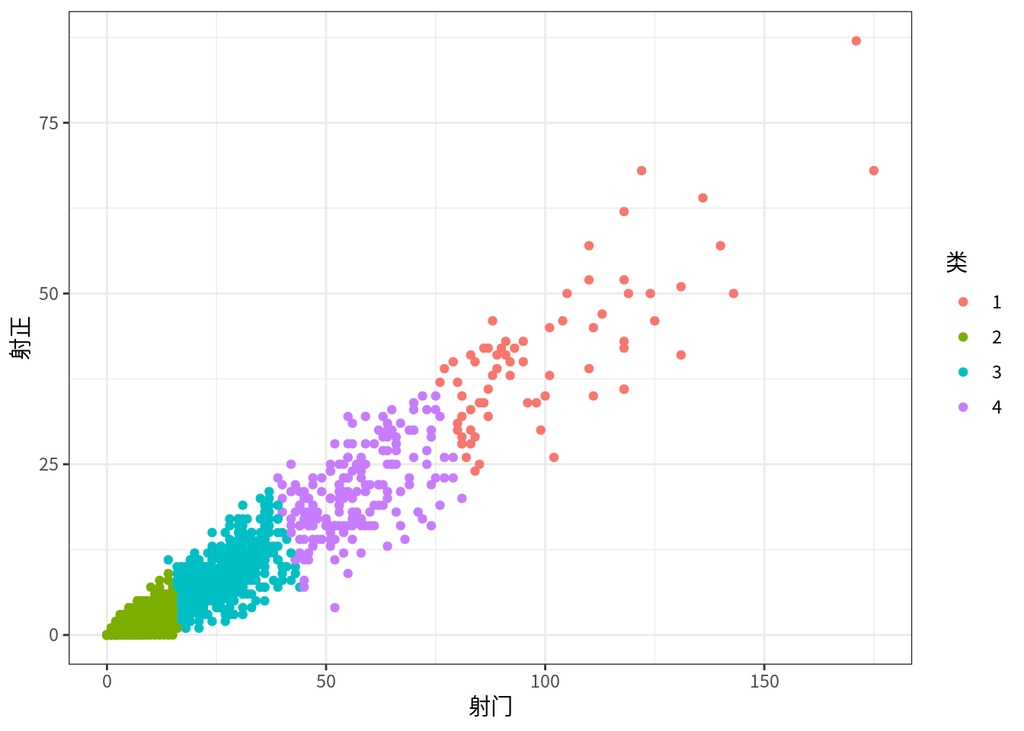

```r
dat <- data_ability[,2:3]
# kmeans
cl <- kmeans(dat, 4)
dat$cluster <- cl$cluster
dat %>%
  ggplot() +
  geom_point(aes(x = 射门, y = 射正, color = as.factor(cluster))) +
  theme_bw() +
  theme(text = element_text(family = "Hei")) +
  labs(color = "类")
```

### DBSCAN

1. 从数据集中任意选取一个数据对象点 p；
2. 如果对于参数 Eps 和 MinPts，所选取的数据对象点 p 为核心点，则找出所有从 p 密度可达的数据对象点，形成一个簇；
3. 如果选取的数据对象点 p 是边缘点，选取另一个数据对象点；
4. 重复（2）、（3）步，直到所有点被处理。

```r
library(fpc)
library(factoextra)
```

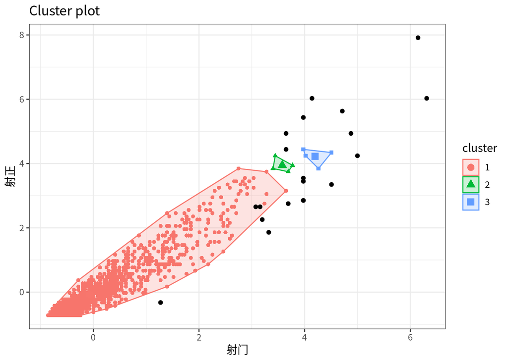

```r
db <- dbscan(dat[,1:2], eps = 0.4, MinPts = 5, scale = T)
fviz_cluster(db, dat[,1:2], stand = T, frame = T, geom = "point") +
  theme_bw() +
  theme(text = element_text(family = "Hei"))
```

```r
library(factoextra)
data("multishapes")
df <- multishapes[,1:2]
```

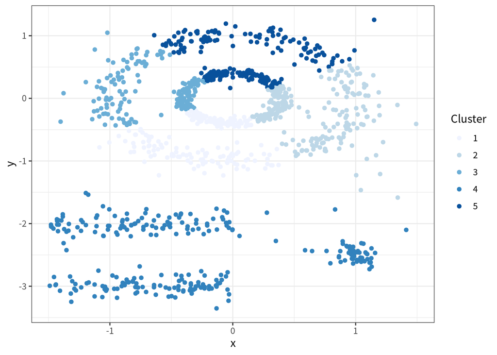

```r
# kmeans
set.seed(1)
cl <- kmeans(df, 5)
df2 <- df
df2$cluster <- cl$cluster
df2 %>%
  ggplot() +
  geom_point(aes(x = x, y = y, color = as.factor(cluster))) +
  theme_bw() +
  theme(text = element_text(family = "Hei")) +
  labs(color = "Cluster") +
  scale_color_brewer()
```

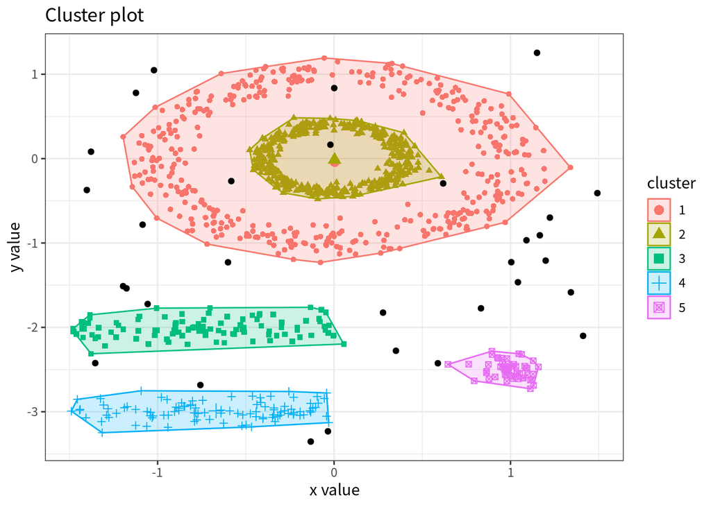

```r
# DBSCAN
set.seed(1)
library(fpc)
db <- dbscan(df, eps = 0.15, MinPts = 5, scale = F)
fviz_cluster(db, df, stand = F, frame = F, geom = "point") +
  theme_bw()
```

## 主成分分析

我们可以使用一些降维的方法来减少变量个数。对这些变量进行对数变换，利用主成分分析的方法，对相关系数矩阵提取主成分，并绘制主成分的崖底碎石图；选择合适的主成分个数，将主成分得分分别存入变量PCA1,PCA2

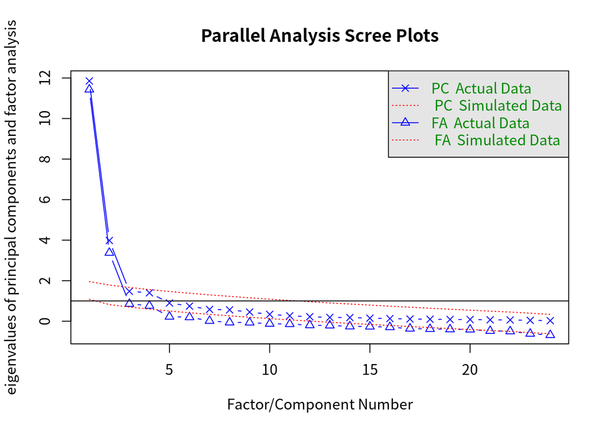

```
## Parallel analysis suggests that the number of factors =  4  and the number of components =  2
```

```r
# 选取需要提取主成分的数据
data_com <- data_ability[,2:25]
# 对数据进行对数变换
data_com <- apply(data_com, 2, function(x) log10(x+1))
# 计算相关系数矩阵
data_com_r <- cor(data_com)
# 计算主成分
pca_fit <- pca(data_com_r,nfactors = 2,rotate = "varimax")
# 崖底碎石图
fa.parallel(data_com_r, n.obs = 112, fa = "both", n.iter = 100)
```

```r
# 计算主成分得分
data_ability$PCA1 <- as.matrix((data_com))%*%(as.vector(pca_fit$loadings[,1]))
data_ability$PCA2 <- as.matrix((data_com))%*%(as.vector(pca_fit$loadings[,2]))
```

解读：根据崖底碎石图，选择主成分个数为2。主成分1主要包括了射正、射门、偷球等指标，我们将它命名为球员进攻能力因子；而主成分2主要包括了解围、拦截等指标，将其命名为球员防守能力指标。

- 对主成分得分划分区间，绘制各个区间对应样本观测的身价均值柱状图，探究主成分得分与球员能力的关系

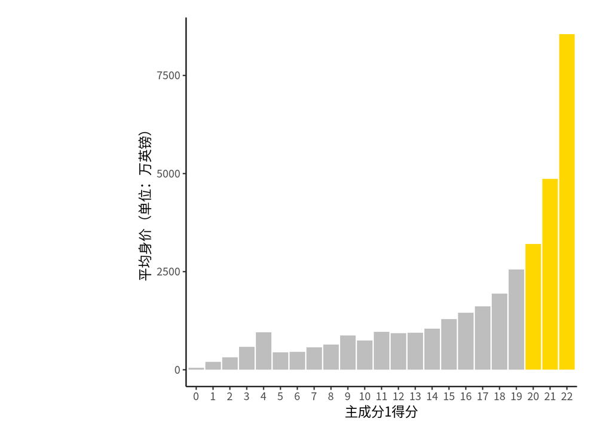

```r
# 计算主成分得分区间身价均值
data_pca1 <- data_ability%>%group_by(round(PCA1,0))%>%summarise(mean = mean(身价,na.rm = T))
colnames(data_pca1)[1] <- "PCA1"
data_pca2 <- data_ability%>%group_by(round(PCA2,0))%>%summarise(mean = mean(身价,na.rm = T))
colnames(data_pca2)[1] <- "PCA2"
# 主成分1
ggplot(data_pca1)+
  geom_bar(aes(x = factor(PCA1),y = mean),fill = c(rep("grey",20),rep("gold",3)),stat = "identity")+
  theme_bw(base_family = "STXihei")+
  # 添加坐标轴标签
  xlab("主成分1得分")+
  ylab("平均身价（单位：万英镑）")+
  # 设置图片大小
  theme(plot.margin = unit(c(1,2,1,8),'lines'))+
  # 设置背景
  theme(panel.border = element_blank(),
        panel.grid.major = element_blank(),
        panel.grid.minor = element_blank(),
        axis.line = element_line(colour = "black"))
```

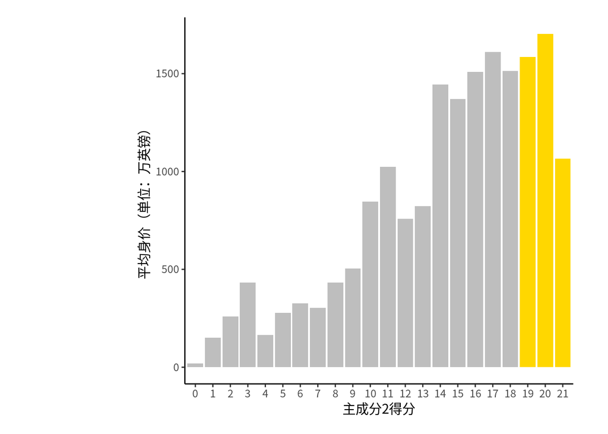

```r
# 主成分2
ggplot(data_pca2)+
  geom_bar(aes(x=factor(PCA2),y=mean),fill=c(rep("grey",19),rep("gold",3)),stat = "identity")+
  theme_bw(base_family = "STXihei")+
  theme(panel.border = element_blank(),#设置背景
        panel.grid.major = element_blank(),
        panel.grid.minor = element_blank(),
        axis.line = element_line(colour = "black"))+
  # 设置图片大小
  theme(plot.margin = unit(c(1,2,1,8),'lines'))+
  # 添加坐标轴标签
  xlab("主成分2得分")+
  ylab("平均身价（单位：万英镑）")
```

**解读：能力越高的球员身价越高，球员身价随着主成分1和主成分2的增加而增加，且身价随主成分1上升的趋势非线性，主成分1得分越高，身价上涨越快。**